# Report-RepProj2

Samuel Chen

2021/12/15

# Severe Weather data analysis for the impact on population health and economy from 1996 to 2011

## Synopsis

Storms and other severe weather events can cause both public health and economic problems for communities and municipalities. Many severe events can result in fatalities, injuries, and property damage, and preventing such outcomes to the extent possible is a key concern.

This project involves exploring the U.S. National Oceanic and Atmospheric Administration’s (NOAA) storm database. This database tracks characteristics of major storms and weather events in the United States, including when and where they occur, as well as estimates of any fatalities, injuries, and property damage.

### Data

The data for this assignment come in the form of a comma-separated-value file compressed via the bzip2 algorithm to reduce its size. You can download the file from the course web site:

- [Storm Data](https://d396qusza40orc.cloudfront.net/repdata%2Fdata%2FStormData.csv.bz2)  
  There is also some documentation of the database available. Here you will find how some of the variables are constructed/defined.
- National Weather Service [Storm Data Documentation](https://d396qusza40orc.cloudfront.net/repdata%2Fpeer2_doc%2Fpd01016005curr.pdf)
- National Climatic Data Center Storm Events [FAQ](https://d396qusza40orc.cloudfront.net/repdata%2Fpeer2_doc%2FNCDC%20Storm%20Events-FAQ%20Page.pdf)

The events in the database start in the year 1950 and end in November 2011. In the earlier years of the database there are generally fewer events recorded, most likely due to a lack of good records. More recent years should be considered more complete.

## Questions

1. Across the United States, which types of events (as indicated in the EVTYPE variable) are most harmful with respect to population health?
2. Across the United States, which types of events have the greatest economic consequences?

## Data Processing

```r
library(tidyverse)
library(lubridate)
```

```r
library(knitr)

##Locate, download and unzip the data file.
fileName<-"repdata_data_StormData.csv.bz2"
fileURL<-"https://d396qusza40orc.cloudfront.net/repdata%2Fdata%2FStormData.csv.bz2"

if(!file.exists(fileName)){
  download.file(fileURL,destfile=fileName,method="curl")
}

##Read the data.
df<-read.csv(fileName)
dim(df)
```

```
## [1] 692288     37
```

```r
names(df)
```

```
##  [1] "STATE__"    "BGN_DATE"   "BGN_TIME"   "TIME_ZONE"  "COUNTY"
##  [6] "COUNTYNAME" "STATE"      "EVTYPE"     "BGN_RANGE"  "BGN_AZI"
## [11] "BGN_LOCATI" "END_DATE"   "END_TIME"   "COUNTY_END" "COUNTYENDN"
## [16] "END_RANGE"  "END_AZI"    "END_LOCATI" "LENGTH"     "WIDTH"
## [21] "F"          "MAG"        "FATALITIES" "INJURIES"   "PROPDMG"
## [26] "PROPDMGEXP" "CROPDMG"    "CROPDMGEXP" "WFO"        "STATEOFFIC"
## [31] "ZONENAMES"  "LATITUDE"   "LONGITUDE"  "LATITUDE_E" "LONGITUDE_"
## [36] "REMARKS"    "REFNUM"
```

```r
str(df)
```

```
## 'data.frame':    692288 obs. of  37 variables:
##  $ STATE__   : chr  "1.00" "1.00" "1.00" "1.00" ...
##  $ BGN_DATE  : chr  "4/18/1950 0:00:00" "4/18/1950 0:00:00" "2/20/1951 0:00:00" "6/8/1951 0:00:00" ...
##  $ BGN_TIME  : chr  "0130" "0145" "1600" "0900" ...
##  $ TIME_ZONE : chr  "CST" "CST" "CST" "CST" ...
##  $ COUNTY    : chr  "97.00" "3.00" "57.00" "89.00" ...
##  $ COUNTYNAME: chr  "MOBILE" "BALDWIN" "FAYETTE" "MADISON" ...
##  $ STATE     : chr  "AL" "AL" "AL" "AL" ...
##  $ EVTYPE    : chr  "TORNADO" "TORNADO" "TORNADO" "TORNADO" ...
##  $ BGN_RANGE : chr  "0.00" "0.00" "0.00" "0.00" ...
##  $ BGN_AZI   : chr  "" "" "" "" ...
##  $ BGN_LOCATI: chr  "" "" "" "" ...
##  $ END_DATE  : chr  "" "" "" "" ...
##  $ END_TIME  : chr  "" "" "" "" ...
##  $ COUNTY_END: chr  "0.00" "0.00" "0.00" "0.00" ...
```

[output cut: 23 more lines]

```r
summary(df)
```

[output not shown]

```r
#Subsetting the raw data set
df_selected<-select(df,BGN_DATE,EVTYPE,FATALITIES,INJURIES,PROPDMG,PROPDMGEXP,CROPDMG,CROPDMGEXP)
df_selected <- df %>%
  dplyr::select(BGN_DATE,EVTYPE,FATALITIES,INJURIES,PROPDMG,PROPDMGEXP,CROPDMG,CROPDMGEXP) %>%
  mutate(BGN_DATE = str_remove(BGN_DATE, " 0:00:00")) %>%
  mutate(BGN_DATE = mdy(BGN_DATE))
head(df_selected)
```

```
##     BGN_DATE  EVTYPE FATALITIES INJURIES PROPDMG PROPDMGEXP CROPDMG CROPDMGEXP
## 1 1950-04-18 TORNADO       0.00    15.00   25.00          K    0.00
## 2 1950-04-18 TORNADO       0.00     0.00    2.50          K    0.00
## 3 1951-02-20 TORNADO       0.00     2.00   25.00          K    0.00
## 4 1951-06-08 TORNADO       0.00     2.00    2.50          K    0.00
## 5 1951-11-15 TORNADO       0.00     2.00    2.50          K    0.00
## 6 1951-11-15 TORNADO       0.00     6.00    2.50          K    0.00
```

```r
df_selected<-subset(df_selected,year(BGN_DATE)>"1995"& year(BGN_DATE)<=2011)

##Format transformations
df_selected$FATALITIES<-as.numeric(df_selected$FATALITIES)
df_selected$INJURIES<-as.numeric(df_selected$INJURIES)
df_selected$PROPDMG<-as.numeric(df_selected$PROPDMG)
df_selected$CROPDMG<-as.numeric(df_selected$CROPDMG)
```

## Solution 1: Population health related event

The variables for the impact on public health are “FATALITIES” and “INJURIES”. So we are going to draw the subset regarding these 2 variables and the one stands for the event, EVTYPE.

```r
##Draw the data set just for the number of fatalities and injuries.
head(df_selected)
```

```
##          BGN_DATE       EVTYPE FATALITIES INJURIES PROPDMG PROPDMGEXP CROPDMG
## 248768 1996-01-06 WINTER STORM          0        0     380          K      38
## 248769 1996-01-11      TORNADO          0        0     100          K       0
## 248770 1996-01-11    TSTM WIND          0        0       3          K       0
## 248771 1996-01-11    TSTM WIND          0        0       5          K       0
## 248772 1996-01-11    TSTM WIND          0        0       2          K       0
## 248773 1996-01-18         HAIL          0        0       0                  0
##        CROPDMGEXP
## 248768          K
## 248769
## 248770
## 248771
## 248772
## 248773
```

```r
dim(df_selected)
```

```
## [1] 298776      8
```

```r
PHDMG<-aggregate(data=df_selected,FATALITIES+INJURIES~EVTYPE, FUN="sum")
dim(PHDMG)
```

```
## [1] 504   2
```

```r
##Manipulate the data set.
str(PHDMG)
```

```
## 'data.frame':    504 obs. of  2 variables:
##  $ EVTYPE               : chr  "   HIGH SURF ADVISORY" " COASTAL FLOOD" " FLASH FLOOD" " LIGHTNING" ...
##  $ FATALITIES + INJURIES: num  0 0 0 0 0 0 0 0 0 0 ...
```

```r
summary(PHDMG)
```

```
##     EVTYPE          FATALITIES + INJURIES
##  Length:504         Min.   :   0.0
##  Class :character   1st Qu.:   0.0
##  Mode  :character   Median :   0.0
##                     Mean   :  81.4
##                     3rd Qu.:   1.0
##                     Max.   :9941.0
```

```r
##Rename the variables.
names(PHDMG)<-c("EVTYPE","DMG")
PHDMG$EVTYPE<-str_trim(PHDMG$EVTYPE)
##Filter the records in which the damage (fatalities + injuries) are not 0.
PHDMG_NoZero<-subset(PHDMG,DMG>0)
##Reorder the data set with DMG descending.
PHDMG_NoZero<-PHDMG_NoZero[order(-PHDMG_NoZero$DMG),]
```

Now the data frame PHDMG_NoZero is the one we need. Go to the “Results” section to find out the final conclusion.

## Solution 2: Economic Consequenses related event.

Like the previous question, we need to find out the variables telling the stories about the impact on the economy of the events. We found these variables are the ones we need: PROPDMG,PROPDMGEXP,CROPDMG,CROPDMGEXP.  
Like before, the first we are going to do is to draw a subset for this topic.

```r
ev_econ<-subset(df_selected,PROPDMG>0&CROPDMG>0)
ev_econ<-select(ev_econ,EVTYPE,PROPDMG,PROPDMGEXP,CROPDMG,CROPDMGEXP)
table(ev_econ$PROPDMGEXP)
```

```
##
##    B    K    M
##    7 6988  588
```

```r
table(ev_econ$CROPDMGEXP)
```

```
##
##    K    M
## 6984  599
```

We found the variables “…EXP” means “exponents” and the values are “K”,“M” and “B”. Apparently they stand for Kilo, Million and Billion. So we are going to transform them and sum the value up to a single variable that stands for the economic consequence, ECODMG.

```r
ev_econ$PROPDMGfct[ev_econ$PROPDMGEXP=="K"]<-10^3
ev_econ$PROPDMGfct[ev_econ$PROPDMGEXP=="M"]<-10^6
ev_econ$PROPDMGfct[ev_econ$PROPDMGEXP=="B"]<-10^9

ev_econ$CROPDMGfct[ev_econ$CROPDMGEXP=="K"]<-10^3
ev_econ$CROPDMGfct[ev_econ$CROPDMGEXP=="M"]<-10^6
ev_econ$CROPDMGfct[ev_econ$CROPDMGEXP=="B"]<-10^9

ev_econ<-mutate(ev_econ,ECODMG=PROPDMG*PROPDMGfct+CROPDMG*CROPDMGfct)
ev_econ_dmg<-aggregate(data=ev_econ,ECODMG~EVTYPE,FUN="sum")
max(ev_econ_dmg$ECODMG)
```

```
## [1] 19610970800
```

```r
##Reorder the data set with ECODMG descending.
ev_econ_dmg<-ev_econ_dmg[order(-ev_econ_dmg$ECODMG),]
```

Just like before, let’s make a plot to show the result.

## Results

After the data processing and analysis above, the results for the questions will be showed with 2 plots. Let’s take a look.  
### Across the United States, which types of events (as indicated in the EVTYPE variable) are most harmful with respect to population health?

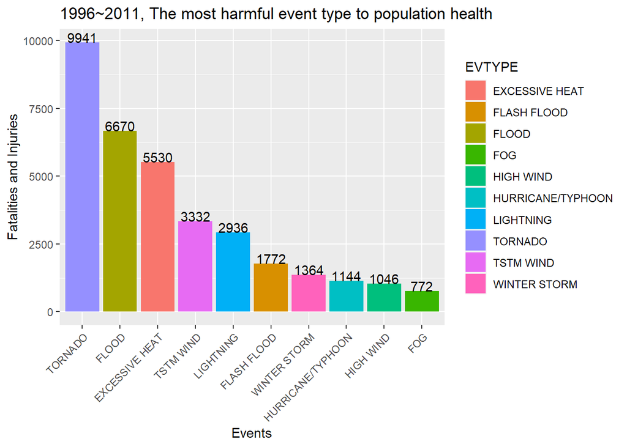

```r
ggplot(data=PHDMG_NoZero[1:10,],aes(x=reorder(EVTYPE,-DMG),y=DMG,fill=EVTYPE,label=DMG))+geom_col()+
  geom_text(vjust=0)+
  theme(axis.text.x = element_text(angle = 45, hjust = 1)) +
  xlab("Events") + ylab("Fatalities and Injuries")+
  ggtitle("1996~2011, The most harmful event type to population health")
```

From the plot, Tornado was the most harmful event type that impact the public health in the range of 1996~2011.  
### Across the United States, which types of events have the greatest economic consequences?

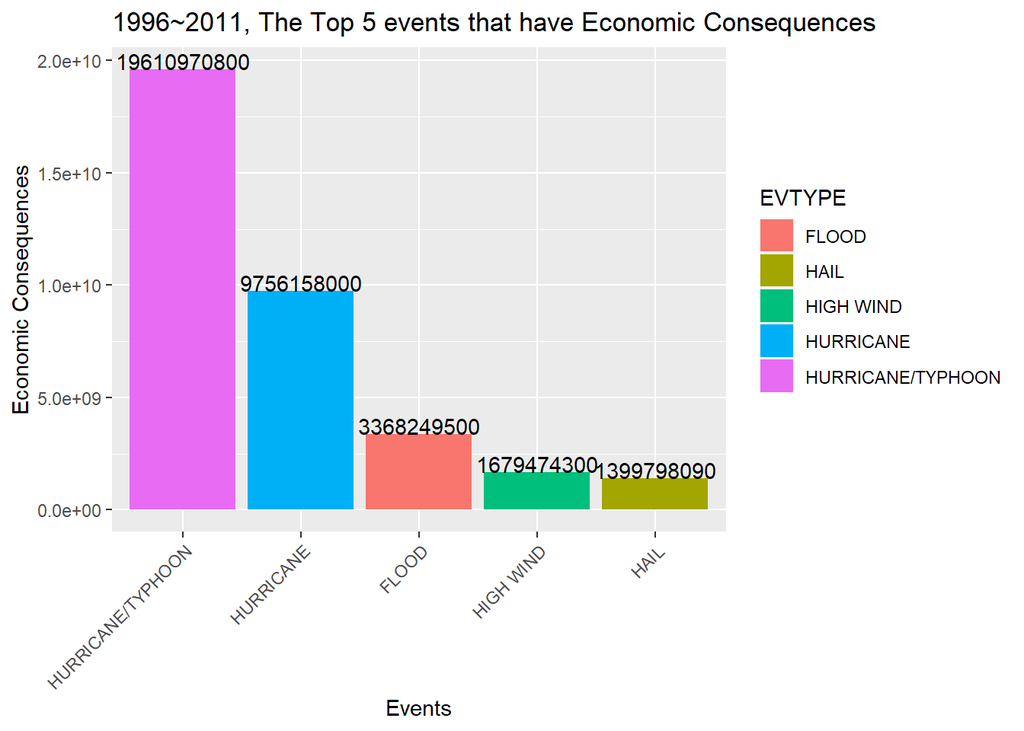

```r
ggplot(data=ev_econ_dmg[1:5,],aes(x=reorder(EVTYPE,-ECODMG),y=ECODMG,fill=EVTYPE,label=ECODMG))+geom_col()+
  geom_text(vjust=0)+
  theme(axis.text.x = element_text(angle = 45, hjust = 1)) +
  xlab("Events") + ylab("Economic Consequences")+
  ggtitle("1996~2011, The Top 5 events that have Economic Consequences")
```

Hurricane/Typhoon is the result to the 2nd question.